# Statistical Inference Project

Guy Cole

October 2, 2016

# Simulation Exercise

## Overview

Investigate the exponential distribution in R and compare it w/the Central Limit Theorem.

As mandated by assignment, exponential distribution will be simulated in R using rexp(n, lambda) where lambda is the rate parameter. Distribution mean and standard deviation are 1/lambda and lambda = 0.2 for all simulations.

Assigment mandates investigation of “distribution of averages of 40 exponentials” w/1000 simulations.

## Simulations

Initialization.

```r
set.seed(54321)
lambda <- 0.2
n <- 40
simulationLimit <- 1000
standardDeviation <- 1/lambda
```

## Sample Mean vs Theoretical Mean

```r
simulation <- rexp(simulationLimit * n, rate = lambda)

simulatedMean <- mean(simulation)
simulatedMean
```

```
## [1] 4.990132
```

```r
theoreticalMean <- 1/lambda
theoreticalMean
```

```
## [1] 5
```

## Sample Variance vs Theoretical Variance

```r
datum <- NULL
for (ii in 1:simulationLimit) {
  datum <- c(datum, mean(rexp(n, lambda)))
}
```

### Illustrate sample mean vs theoretical mean.

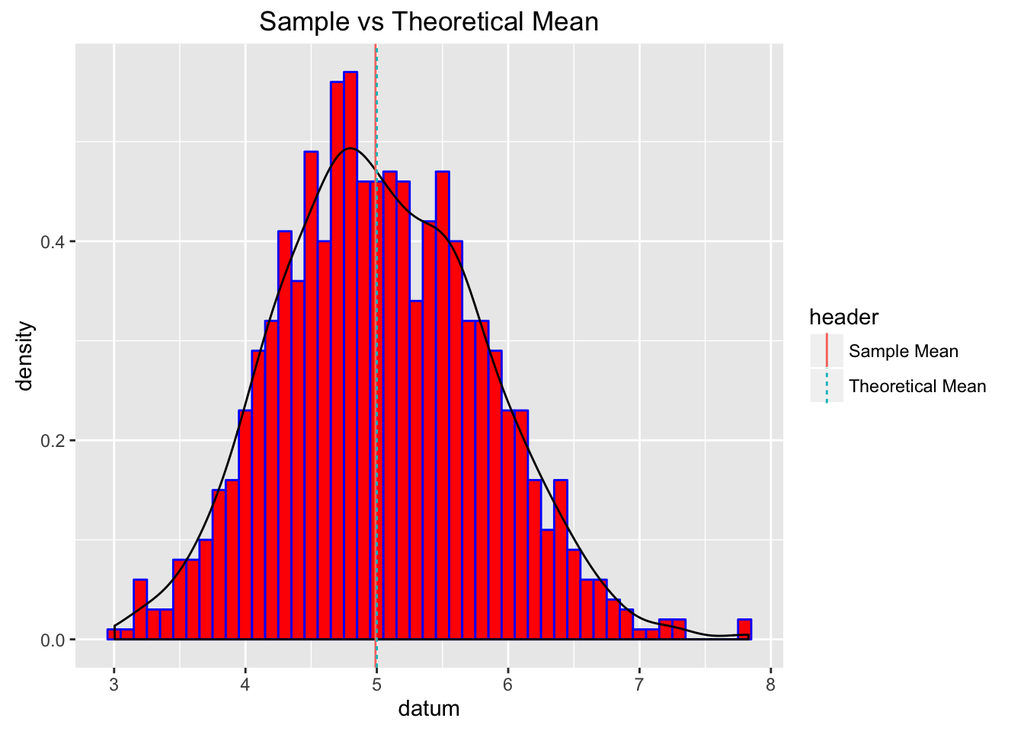

```r
library(ggplot2)

dataFrame1 <- data.frame(header = c("Sample Mean", "Theoretical Mean"), values = c(simulatedMean, theoreticalMean))

gg <- ggplot(NULL, aes(x=datum))

plot1 <- gg + geom_histogram(aes(y=..density..), color="blue", fill="red", binwidth=0.1) + labs(title = "Sample vs Theoretical Mean") + geom_density(color="black") + geom_vline(data=dataFrame1, aes(xintercept=values, linetype=header, color=header), show.legend=TRUE)

plot1
```

Standard deviation

```r
sd(datum)
```

```
## [1] 0.7773352
```

Variance

```r
varianceDatum <- sd(datum)^2
varianceDatum
```

```
## [1] 0.60425
```

Theoretical variance

```r
theoreticalDatum <- (1/lambda)^2/n
theoreticalDatum
```

```
## [1] 0.625
```

## Normal Distribution

The distribution plot (above) clearly exhibits gaussian bell curve shape, indicated normal distribution. Plot below uses qqnorm() to compare simulation to normal, indicating close approximation.

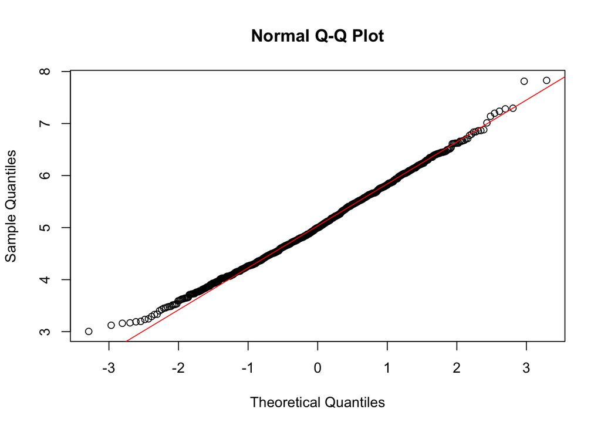

```r
qqnorm(datum)
qqline(datum, col=10)
```

# Tooth Growth

## Overview

Explore the R datasets “ToothGrowth” data.

“ToothGrowth” captures the length of teeth in ten guinea pigs w/three dose levels of Vitamin C (0.5, 1 and 2 mg), delivered via orange juice or ascorbic acid.

```r
library(dplyr)
library(knitr)
library(datasets)

data("ToothGrowth")
```

Data Dictionary

- [,1] len numeric Tooth length
- [,2] supp factor Supplement type (VC or OJ).
- [,3] dose numeric Dose in milligrams.

```r
str(ToothGrowth)
```

```
## 'data.frame':    60 obs. of  3 variables:
##  $ len : num  4.2 11.5 7.3 5.8 6.4 10 11.2 11.2 5.2 7 ...
##  $ supp: Factor w/ 2 levels "OJ","VC": 2 2 2 2 2 2 2 2 2 2 ...
##  $ dose: num  0.5 0.5 0.5 0.5 0.5 0.5 0.5 0.5 0.5 0.5 ...
```

```r
head(ToothGrowth)
```

```
##    len supp dose
## 1  4.2   VC  0.5
## 2 11.5   VC  0.5
## 3  7.3   VC  0.5
## 4  5.8   VC  0.5
## 5  6.4   VC  0.5
## 6 10.0   VC  0.5
```

```r
summary(ToothGrowth)
```

```
##       len        supp         dose
##  Min.   : 4.20   OJ:30   Min.   :0.500
##  1st Qu.:13.07   VC:30   1st Qu.:0.500
##  Median :19.25           Median :1.000
##  Mean   :18.81           Mean   :1.167
##  3rd Qu.:25.27           3rd Qu.:2.000
##  Max.   :33.90           Max.   :2.000
```

## Initial Analysis

Initial analysis indicates that longer tooth length correlates to higher vitamin C dosage.

```r
summaryDataFrame <- ToothGrowth %>% group_by(supp, dose) %>% summarise(count = n(), mean=mean(len), median=median(len), "standard deviation" = sd(len))

kable (summaryDataFrame ,digits = 3, align = 'c')
```

| supp | dose | count | mean | median | standard deviation |
| --- | --- | --- | --- | --- | --- |
| OJ | 0.5 | 10 | 13.23 | 12.25 | 4.460 |
| OJ | 1.0 | 10 | 22.70 | 23.45 | 3.911 |
| OJ | 2.0 | 10 | 26.06 | 25.95 | 2.655 |
| VC | 0.5 | 10 | 7.98 | 7.15 | 2.747 |
| VC | 1.0 | 10 | 16.77 | 16.50 | 2.515 |
| VC | 2.0 | 10 | 26.14 | 25.95 | 4.798 |

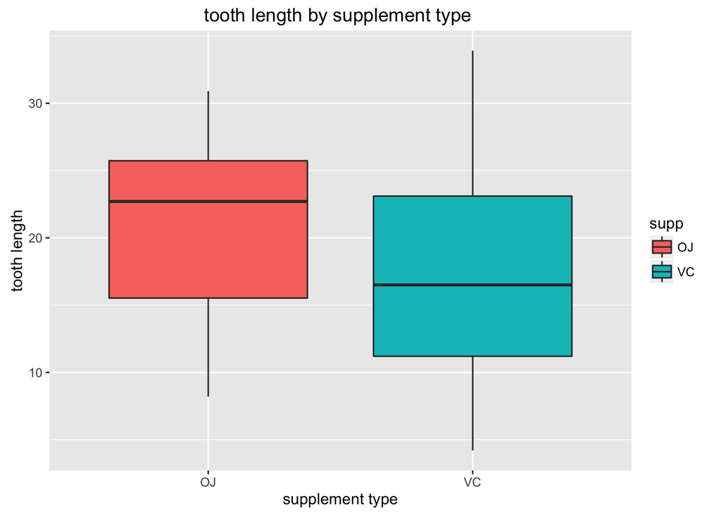

```r
ggplot(data=ToothGrowth, aes(x=supp, y=len))+
        geom_boxplot(aes(fill=supp))+
        xlab("supplement type") +
        ylab("tooth length")+
        ggtitle("tooth length by supplement type ")
```

## Confidence Interval Testing

Employ t test to verify null hypotheses (both supply menthods produce same results).

```r
t.test(ToothGrowth$len[ToothGrowth$supp=="OJ"], ToothGrowth$len[ToothGrowth$supp=="VC"], paired=FALSE, var.equal=FALSE)
```

```
##
##  Welch Two Sample t-test
##
## data:  ToothGrowth$len[ToothGrowth$supp == "OJ"] and ToothGrowth$len[ToothGrowth$supp == "VC"]
## t = 1.9153, df = 55.309, p-value = 0.06063
## alternative hypothesis: true difference in means is not equal to 0
## 95 percent confidence interval:
##  -0.1710156  7.5710156
## sample estimates:
## mean of x mean of y
##  20.66333  16.96333
```

Test increasing dose from 0.5 to 1.

```r
t.test(ToothGrowth$len[ToothGrowth$dose==0.5], ToothGrowth$len[ToothGrowth$dose==1], paired=FALSE, var.equal=TRUE)
```

```
##
##  Two Sample t-test
##
## data:  ToothGrowth$len[ToothGrowth$dose == 0.5] and ToothGrowth$len[ToothGrowth$dose == 1]
## t = -6.4766, df = 38, p-value = 1.266e-07
## alternative hypothesis: true difference in means is not equal to 0
## 95 percent confidence interval:
##  -11.983748  -6.276252
## sample estimates:
## mean of x mean of y
##    10.605    19.735
```

Dramatically lower p value (1.266e-07) implies dosage impacts mean.

```r
t.test(ToothGrowth$len[ToothGrowth$dose==1], ToothGrowth$len[ToothGrowth$dose==2], paired=FALSE, var.equal=TRUE)
```

```
##
##  Two Sample t-test
##
## data:  ToothGrowth$len[ToothGrowth$dose == 1] and ToothGrowth$len[ToothGrowth$dose == 2]
## t = -4.9005, df = 38, p-value = 1.811e-05
## alternative hypothesis: true difference in means is not equal to 0
## 95 percent confidence interval:
##  -8.994387 -3.735613
## sample estimates:
## mean of x mean of y
##    19.735    26.100
```

Which also yields a very low p value (1.811e-05) which implies that increased vitamin C dosage encourages tooth growth.

## Conclusion

Analysis using t-tests indicate that delivery methods do not impact tooth growth. Increased levels of vitamin C dosage encourages increased tooth growth.